# The Cable Buys Headroom: 91% of a USB 2.0 Bus, 3.6% of a Thunderbolt One

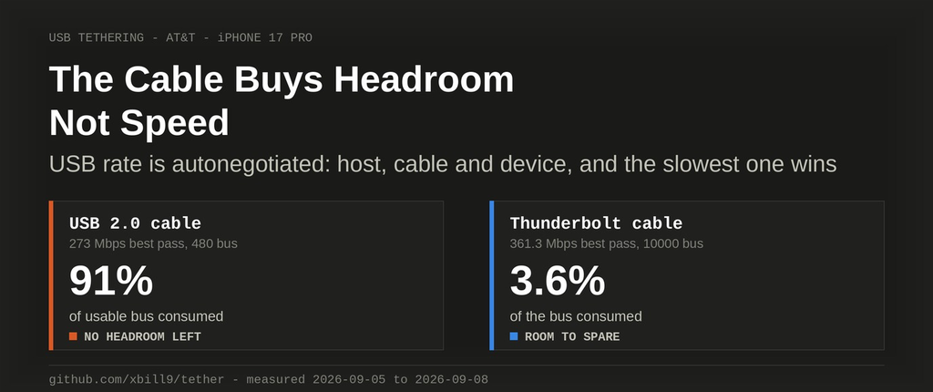

This article walks through diagnosing a USB tether that would not negotiate above USB 2.0 speed, on a phone that advertises 10 Gb/s. The hunt took four cables and three physical ports across two days.

**USB link speed is autonegotiated between the host, the cable and the device, and the result is the slowest mode all three can manage.** The cable is a full participant in that negotiation, a USB 2.0 cable has no way to vote for anything above 480 Mbps, and **nothing anywhere reports that it happened.** The tether comes up, DHCP works, traffic flows, and the link is capped at a fifth of what both ends were offering.

What the right cable buys is not speed. It is **headroom**, and the difference is not subtle: the best USB 2.0 pass in this log used **91% of what that bus can usably carry**, while the same link on a SuperSpeed cable uses **3.6%**.

Every command below is one you can run against your own tether, and every number comes from a record in the repository:

https://github.com/xbill9/tether

#### The Symptom

The repository holds 45 measurement records across 14 handsets from four vendors, each one a full pass — three sequential single-stream transfers, a four-stream parallel test, and a ping — against a fixed endpoint and a fixed 8 MB transfer size.

**41 of those 45 records enumerated at 480 Mbps.** Fourteen handsets, three drivers, two carriers, three physical receptacles, and for two days not one USB 3.0 negotiation anywhere.

The most conspicuous offender was an iPhone 17 Pro, whose BOS descriptor is not shy about what it can do:

```
bcdUSB               2.10
SuperSpeed USB Device Capability:
  wSpeedsSupported   0x000e     -> Full, High, SuperSpeed (5Gbps)
SuperSpeedPlus USB Device Capability:
  bmSublinkSpeedAttr[0]  10Gb/s Symmetric RX SuperSpeedPlus
  bmSublinkSpeedAttr[1]  10Gb/s Symmetric TX SuperSpeedPlus
```

A device declaring 10 Gb/s, enumerating at 480 Mbps. That is a factor of about twenty-one, and it is the kind of gap that makes you stop measuring throughput and start reading `sysfs`.

#### The Bus Rate Is Negotiated, and Every Link in the Chain Votes

USB link speed is not a property of the phone, and it is not a property of the laptop. It is negotiated at every attach between three parties — host controller, cable, device — and **the trained rate is the fastest mode all three can do.** One USB 2.0 component anywhere in that chain and the entire link comes up at 480 Mbps.

The cable is a real participant in that vote, not a passive wire. SuperSpeed rides on two extra differential pairs that a USB 2.0 cable does not physically contain — it carries `D+`/`D-` and nothing else. Put one between a 10 Gb/s phone and a 10 Gb/s port and the two ends will negotiate down to High Speed and work perfectly.

**And nothing tells you.** No error, no `dmesg` warning, no degraded-mode indicator, no line anywhere saying a cable capped you. The only evidence is a number in `sysfs` that you have to go and read, next to a second number saying what the device had offered:

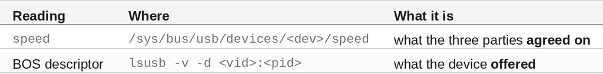

**The gap between those two numbers is the cable's vote.** Steps 1 and 2 below are those two readings, and everything after them is narrowing down which participant cast the low one.

#### At This Point You Should Have

- A phone tethered over USB and holding the default route — check this first, or you will measure Wi-Fi
- `lsusb` from `usbutils`, and `ip` from `iproute2`
- Read access to `/sys/bus/usb/devices` and `/sys/class/net`, which needs no root
- Every other route-capable interface **down**. If Wi-Fi is up, `curl` will succeed over it and the result will look like a tethering measurement

None of the diagnosis below transfers a single byte over the cellular link. That matters here: a full measurement pass in this repository costs roughly 56 MB of metered data, and everything in Steps 1 through 4 is free.

#### Step 1 — Read the Bus Speed First

This is the one reading that invalidates everything downstream if you skip it. A charge-only or USB 2.0 cable silently caps the bus at 480 Mbps and nothing anywhere reports an error.

```bash
# find the tether interface and its USB device
for i in /sys/class/net/*/device/driver; do
  ifn=$(basename $(dirname $(dirname $i)))
  drv=$(basename $(readlink -f $i))
  case $drv in cdc_ncm|rndis_host|ipheth) echo "$ifn  $drv";; esac
done
enxb65575abcda3  ipheth
```

Then walk from the interface back to the USB device and read its trained speed:

```bash
dev=$(basename $(readlink -f /sys/class/net/enxb65575abcda3/device/..))
cat /sys/bus/usb/devices/$dev/speed
480
```

`480` is USB 2.0, `5000` is USB 3.0 Gen 1, `10000` is Gen 2. Alongside it, `/sys/class/net/<if>/speed` gives the negotiated link rate — though note that `ipheth` returns `EINVAL` there and reports nothing, so on an iPhone this field stays blank in every record.

#### Step 2 — Ask the Device What It Is Capable Of

A 480 reading only means something once you know what the device brought to the negotiation.

```bash
lsusb -v -d 05ac:12a8 2>/dev/null | grep -A3 "SuperSpeed"
```

The descriptor block at the top of this article is that output. **The device capability is the control.** Compare the iPhone 16e measured eight minutes before the fastest pass in this log: it advertises no SuperSpeed capability at all, so its 480 is its own ceiling and no cable on earth will move it.

That single distinction separates "something in the chain voted 480" from "the phone itself voted 480", and it is free to read. Where the device offers SuperSpeed and the link trained at High Speed, one of the other two participants is responsible — and there are only two of them.

#### Step 3 — Find Every Port, Not Just the Pretty Ones

This step exists because the investigation got it wrong, in print, twice.

The obvious move on a modern laptop is to enumerate the Type-C connectors, since the kernel binds each one to its USB ports at boot:

```bash
dmesg | grep "typec port"
typec port0: bound usb3-port1 (ops connector_ops [usbcore])
typec port0: bound usb4-port1 (ops connector_ops [usbcore])
typec port1: bound usb3-port2 (ops connector_ops [usbcore])
typec port1: bound usb2-port1 (ops connector_ops [usbcore])
```

Read against `lspci`, that is a complete map of the machine's USB-C:

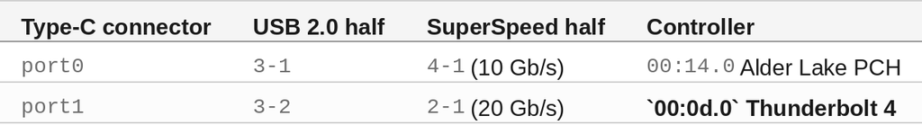

That table is correct. The conclusion drawn from it — *"there is no untried port on this machine"* — was wrong, and it cost about an hour.

**`/sys/class/typec` enumerates Type-C connectors only.** A Type-A receptacle has no Power Delivery and therefore no connector object, so it cannot appear there. The machine had a third external receptacle the map could not see.

Take the port inventory from the hotplug entries in the port list instead:

```bash
for p in /sys/bus/usb/devices/usb*/*/usb*-port*; do
  [ "$(cat $p/connect_type 2>/dev/null)" = "hotplug" ] || continue
  peer="-"; [ -L "$p/peer" ] && peer=$(basename "$(readlink -f "$p/peer")")
  echo "$(basename $p)  peer=$peer  location=$(cat $p/location)"
done | sort
usb3-port3  peer=usb4-port2  location=0x80000301
usb4-port2  peer=usb3-port3  location=0x80000301
```

`usb3-port3` is the USB-A receptacle. Its `peer` is a 10 Gb/s port on another hub, and the shared `location` is the kernel saying *these two entries are two halves of one physical hole in the side of the laptop*.

**That peer relationship is the single most useful line in this whole investigation**, for a reason that only becomes clear in a moment.

#### Step 4 — Ask the Cable Directly, and Watch It Refuse

An electronically marked USB-C cable declares its own data capability over Power Delivery, and Linux exposes that as a `portN-cable` device with an `identity/` directory of PD VDOs. The USB-C specification **requires** an e-marker on a passive cable supporting more than USB 2.0, and does not require one on a USB 2.0 cable. So a missing e-marker would be real evidence.

```bash
ls /sys/class/typec/
cat /sys/class/typec/port0-partner/usb_power_delivery_revision
port0  port0-partner  port1  usb_power_delivery_revision
0.0
```

**There is no cable node, and that is not evidence about the cable.** The stack is not surfacing VDO data at all: the connected partner — the phone itself — has an empty `identity/` directory and reports PD revision `0.0`. A stack that will not show the phone's PD identity was never going to show the cable's.

Worth knowing precisely because it looks like it should work. On a host that does report cable identity this is the whole answer in one `cat`. Here it is silence, not a finding, and treating it as a finding would have convicted the cable on no evidence.

#### The Hunt

With the cable unreadable, the only remaining instrument is substitution. Four cables, three receptacles, over one afternoon:

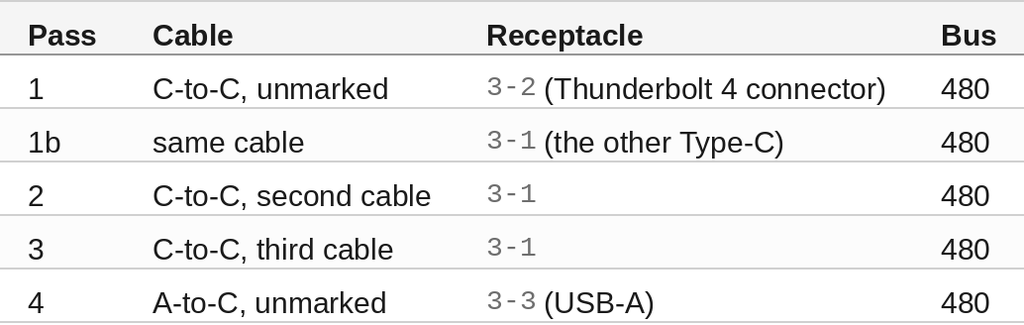

Zero USB errors and zero drops in every pass. The host has two SuperSpeed root hubs, both enumerated, both idle, and neither had ever seen a device.

**The tempting reading is that four negatives is mounting evidence against the host. It is not.** None of those four cables was *known* to carry SuperSpeed pairs. Unmarked C-to-C cables — the kind that ship in the box with a phone or a charger — are overwhelmingly USB 2.0 by construction. Four of them all being USB 2.0 is not a coincidence in need of explanation; it is the expected outcome.

Four unknowns is close to one result repeated, not four independent tests.

#### The Trap in the Middle

Here is the part of the investigation most worth stealing, because it has nothing to do with USB.

Throughput was measured on every one of those passes, and it moved a great deal:

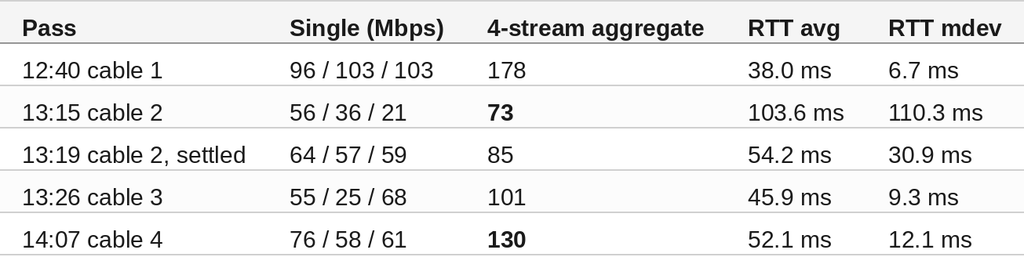

**None of that is a cable effect.** The carrier was recovering from a dip across the afternoon, and each swap happened to coincide with a step of that recovery. Time is the variable that moved; the cable is the one that did not. The USB errors were zero throughout, and a cable degrading throughput by 60% would show up in those counters.

Two rules came out of this and both are now in the repository's methodology:

1. **Record three single-stream runs, never one.** One phone in this log produced 15, 44 and 116 Mbps on three consecutive identical transfers. Any single number is a lie about the link.
2. **A/B a hardware change against time, not against the previous hour.** If you cannot interleave, do not attribute.

#### The Cable That Worked

The next day, a new USB-A to USB-C cable — around $15, bought specifically to be a *known* SuperSpeed cable rather than another unknown.

```
480  ->  5000
```

The iPhone trained SuperSpeed and moved to a different hub in `sysfs`, appearing at `4-2` rather than the `3-x` of every previous pass. That looks like a port change and it is not:

```
usb4-port2  peer=usb3-port3  location=0x80000301
```

`4-2` is `usb4-port2`, whose peer is `usb3-port3` — the same USB-A receptacle tested at 480 the day before, same location code. **The device moved hubs only because it started training SuperSpeed, which is exactly what a successful 5 Gb/s negotiation looks like on this host.** The receptacle is a control here. The cable is the only variable that moved.

A Pixel 9a on the same new cable, same receptacle, same DHCP lease, confirmed it from the other side:

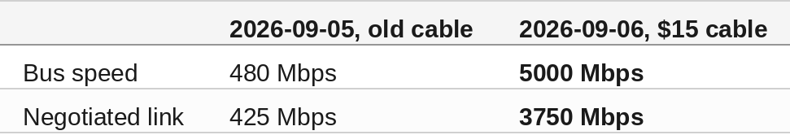

Two handsets, one cable swap, and the question that had eaten an afternoon was answered. The unmarked cables were USB 2.0 cables. ✅

#### What the Cable Unlocked: Headroom

The bus reading is the headline. **Headroom is what it actually buys**, and it is the number that says whether any of this was worth $15.

The repository's diagnostic constant for the realistic bulk throughput of a 480 Mbps USB 2.0 bus, after protocol overhead, is **300 Mbps**. Measure every pass in the log as a share of the bus it ran on and the picture is stark:

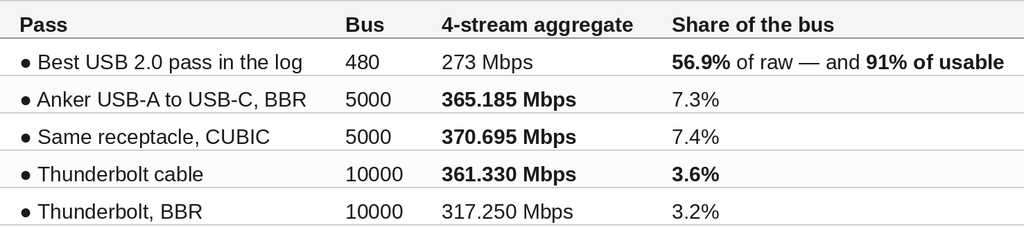

**91% against 3.6% is the whole argument**, and the two denominators are worth naming so the comparison is read correctly. The 91% is 273 Mbps against the **usable** 300 Mbps of a 480 Mbps bus; the 3.6% is 361.330 against the **raw** 10000, because this repository has no measured usable ceiling for a SuperSpeed bus and inventing one would be worse than the mismatch. Compared raw to raw it is **56.9% against 3.6%** — a factor of sixteen rather than twenty-five, and the same conclusion either way.

*Share of the bus is arithmetic throughout — each record's 4-stream aggregate over its own `bus_speed_mbps`, so 273/480 = 56.9% and 365.185/5000 = 7.3%. The 91% figure is 273 against the 300 Mbps usable ceiling rather than the raw 480.*

**On USB 2.0 the best pass in 45 records was at 91% of what the bus can usably carry.** There was nothing left. Every good pass in the 480 era was pressed up against a ceiling, and the ones that were not were being held down by the carrier instead.

**On SuperSpeed the same link uses about 7% of the bus.** The cable did not make anything faster by itself; it moved the ceiling from *just above the traffic* to *fourteen times above the traffic*, so the tether is now free to take whatever the radio gives it on any given evening — and this link swings by more than 4x on its own within minutes.

Four of those measurements also clear the 300 Mbps line outright:

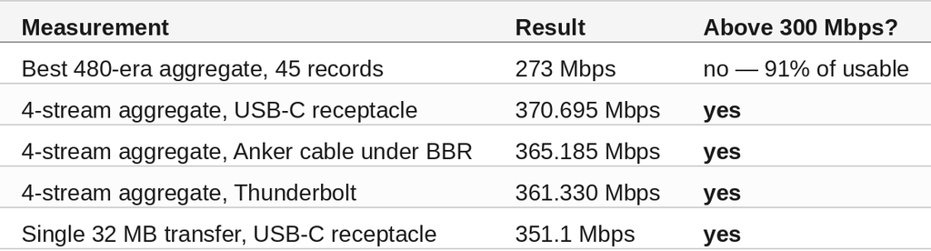

**Those numbers were not reachable on a USB 2.0 bus.** Not "would have been slower" — not reachable. Every one of them needed a cable that could vote for SuperSpeed. ✅

#### Why the Aggregate Is the Test

The four-stream number is doing the work in both tables above, and it is worth saying why rather than treating it as a second opinion on the single-stream figure.

**Single-stream against four-stream aggregate is the one comparison that separates "the carrier is slow" from "something on this machine is collapsing."** If four flows together go much faster than one, the wide-area path has headroom and the problem is local. If they do not, there is no headroom to find.

The Anker cable's BBR pass is a clean worked example. Single-stream ran 134.930 / 113.576 / 123.229 Mbps — a 1.19x spread — against a four-stream aggregate of **365.185 Mbps, 2.95x the single-stream mean.**

Read those two numbers together and the link describes itself. Four flows found nearly three times what one flow did, so the wide-area path plainly had that much to give and nothing local was collapsing: a 1.19x spread with zero errors and zero drops leaves no radio loss for congestion control to misread. **The ceiling in that reading is not on this machine**, which is exactly the state you want to be in — the tether is out of the way and the only thing left is the radio.

The reverse reading is the one that catches people. Where the aggregate lands on top of the single-stream figure, four flows found nothing extra, and no amount of tuning on the host will produce headroom that is not there.

Read the aggregate before you attribute anything to hardware. It is the reading that tells you whether the answer is even on your side of the link.

#### What the Link Reached

Once the bus was out of the way, three passes on this handset across two evenings, on two cables and two host controllers:

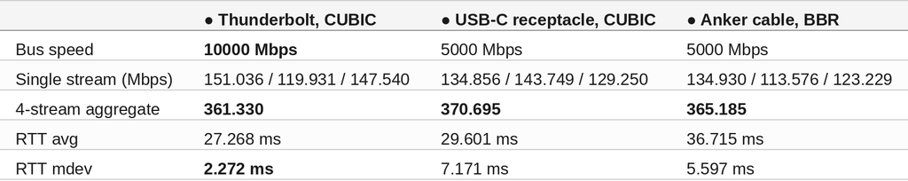

**Three aggregates within 3% of each other — 361.330, 370.695 and 365.185 — across two different cables, two host controllers, two congestion control algorithms and a bus that differs by 2x.** None of those variables moved the number. The link settles around 365 Mbps and the hardware underneath it has stopped mattering, which is what having headroom looks like.

The RTT came with it: 27.268 ms average with `mdev` of **2.272 ms** on the Thunderbolt pass, the flattest jitter anywhere in the log.

The BBR column is worth its place for a second reason. Every early SuperSpeed pass ran `cubic` where the 480-era records ran `bbr`, so bus and congestion control had moved together and neither could be credited. Matched on the same port and bus, BBR gives 365.185 against CUBIC's 370.695 — within a few percent, with `mdev` slightly lower. **The bus is what these figures rest on.**

#### Buy Headroom Once, and Stop

Note the third column of that table: moving from the Thunderbolt port back to a plain USB-C receptacle **halved the bus and cost nothing** — 370.695 Mbps against 361.330. At 361 Mbps the phone is using about 3.6% of a 10000 Mbps bus, by arithmetic, against 7.4% of a 5000 Mbps one. Both are miles of headroom. Doubling an already-idle ceiling buys exactly nothing, and Gen 2 is not worth chasing on a tether.

**One limit on all of this, and it is being closed by measurement rather than argument.** The 300 Mbps figure is the repository's diagnostic constant, so the claim above is a bound argument rather than a controlled A/B — no pass has yet put the fast link back onto a USB 2.0 cable to measure what it would cost. That controlled re-test is queued, and it is the number this article most wants.

#### One More Trap: the Transfer Size

While measuring the fast link, the single-stream figure sat near 140 Mbps against a four-stream aggregate of 361 — the classic shape of per-flow carrier shaping, and that is what it was written up as.

It was wrong, and the correction is worth the paragraph.

The design that settled it was six transfers alternating 8 and 32 MB, **the whole run spanning 3.89 seconds** so that link variation could not fall differently on the two sizes:

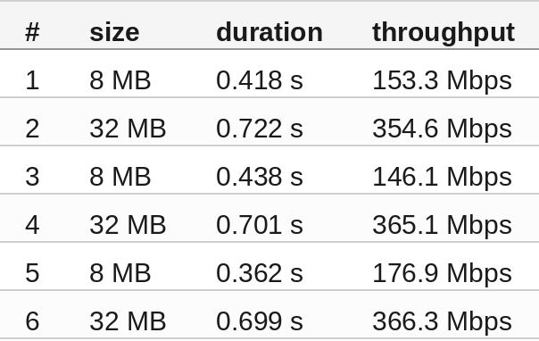

8 MB mean **158.75** Mbps, 32 MB mean **361.96** Mbps, a ratio of **2.28x**. Every 32 MB run beat the 8 MB run beside it, and the two sets do not overlap at all — the fastest 8 MB run, 176.9, is below the slowest 32 MB run, 354.6.

The mechanism is still open. A fixed-cost fit to those durations gives an asymptote of 637 Mbps and a startup cost of **0.305 s**, which is about **10 round trips** at this link's 29.6 ms, where slow-start to the ~503 KB bandwidth-delay product should need roughly 6. Something beyond textbook slow-start is in there, and six transfers cannot say what.

**Same failure mode as the cable, one layer up.** A measurement instrument was producing a number that described the instrument rather than the link, and the only way out was interleaving the two conditions inside a window too short for anything else to change.

#### Cheat Sheet

Both of these are in the repository and run directly, no arguments needed:

```bash
bin/tether-bus-check      # everything below, plus a verdict. No cellular data
bin/tether-report         # the full diagnostic rubric. No cellular data
bin/tether-report --measure   # the standard pass. ~56 MB of metered data
bin/tether-interleave     # A/B two transfer sizes against a moving link
```

`tether-bus-check` reads both sides of the negotiation and says which participant cast the low vote. `tether-interleave` is the design from the section above — alternating sizes back to back so link drift falls on both equally — and it prints the cost before it spends it.

The individual readings, if you would rather run them by hand:

```bash
# 1. which interface is the tether, and what driver
for i in /sys/class/net/*/device/driver; do
  ifn=$(basename $(dirname $(dirname $i)))
  case $(basename $(readlink -f $i)) in
    cdc_ncm|rndis_host|ipheth) echo "$ifn $(basename $(readlink -f $i))";; esac
done

# 2. is it holding the default route (or are you about to measure Wi-Fi)
ip route show default

# 3. THE READING THAT MATTERS - 480 / 5000 / 10000
dev=$(basename $(readlink -f /sys/class/net/<if>/device/..))
cat /sys/bus/usb/devices/$dev/speed

# 4. could the device do better? if no SuperSpeed capability, stop here
lsusb -v -d <vid>:<pid> 2>/dev/null | grep -A3 SuperSpeed

# 5. every external port, including the ones /sys/class/typec cannot see
for p in /sys/bus/usb/devices/usb*/*/usb*-port*; do
  [ "$(cat $p/connect_type 2>/dev/null)" = hotplug ] || continue
  peer="-"; [ -L "$p/peer" ] && peer=$(basename "$(readlink -f "$p/peer")")
  echo "$(basename $p) peer=$peer location=$(cat $p/location)"
done | sort

# 6. errors and drops - non-zero points at cable or power, not config
ip -s link show <if>
```

Steps 1 through 6 cost no cellular data. Only run a transfer once they have told you what you are looking at.

#### Summary

The goal of this article was to find out why a phone advertising 10 Gb/s would not negotiate above USB 2.0 speed on any cable or port, and what fixing it was worth. The key to the solution was treating the link rate as a three-way negotiation and reading both sides of it — what the link agreed on against what the device offered — then reading the port peer map rather than the Type-C connector list, so that a receptacle could be held constant while only the cable changed. The measured results were:

The strategy for using a fixed rubric for USB tethering diagnosis was validated with an incremental step by step approach.